# The Data Science R Bootcamp Assignment

Sanja Cvetković

5/12/2021

## [Assignment Problem 1](http://tanjakec.github.io/Project_DSBC/AssignmentQs.html#Problem_1)

```r
summary(mydata$type_acc)
```

```
##         one_vehicle two_vehicle_no_turn         two_vehicle      parked_vehicle
##                 601                 907                 627                 535
##          pedestrian
##                 163
```

```r
summary(mydata$accident)
```

```
## material_demage          deaths         injured
##            2240               9             584
```

```r
glimpse(mydata)
```

```
## Rows: 2,833
## Columns: 8
## $ id       <int> 1243635, 1240795, 1240864, 1241024, 1240715, 1241608, 1240799…
## $ date     <date> 2019-01-01, 2019-01-01, 2019-01-01, 2019-01-01, 2019-01-01, …
## $ time     <chr> "04:15", "21:05", "16:50", "21:20", "01:50", "05:30", "19:15"…
## $ long     <dbl> 20.49651, 20.46919, 20.45362, 20.47709, 20.26019, 20.45267, 2…
## $ lat      <dbl> 44.81019, 44.79376, 44.79651, 44.81611, 44.29909, 44.88239, 4…
## $ accident <fct> material_demage, material_demage, material_demage, injured, i…
## $ type_acc <fct> parked_vehicle, two_vehicle, two_vehicle_no_turn, two_vehicle…
## $ descrip  <fct> "Sudar sa parkiranim vozilom – bilo sa leve ili sa desne stra…
```

## Which kind of the accident is the most frequent?

### By type_acc feature

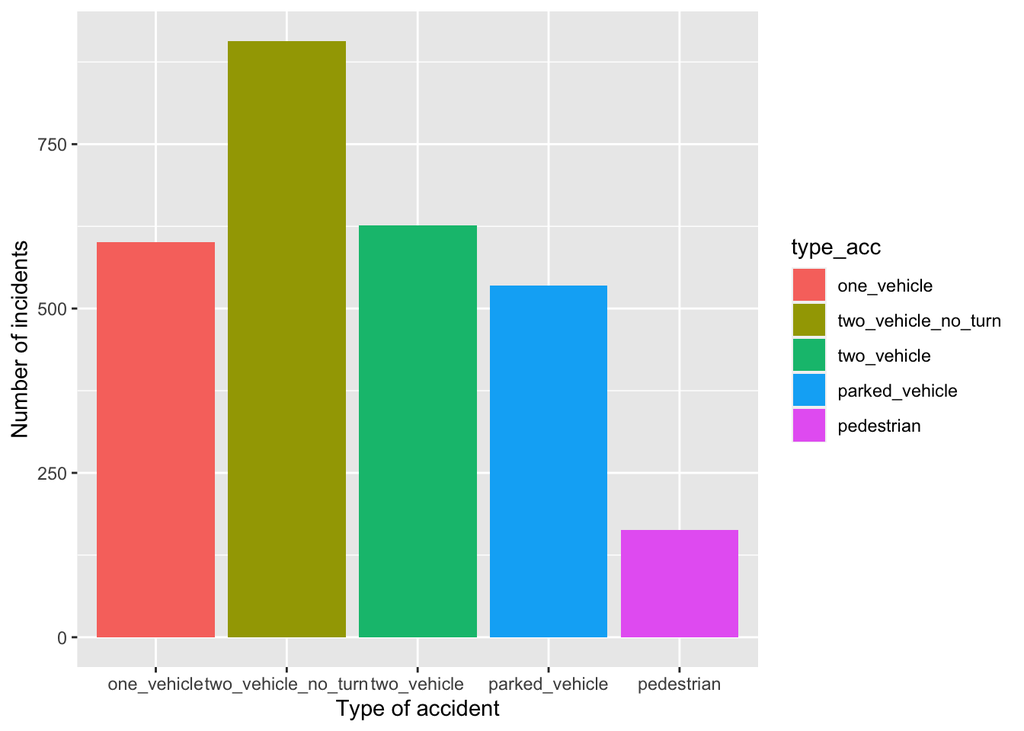

```r
mydata %>%
  group_by(type_acc) %>%
  ggplot(aes(x = type_acc, fill = type_acc)) +
        geom_bar() +
        ylab("Number of incidents") +
        xlab("Type of accident")
```

### By accident feature

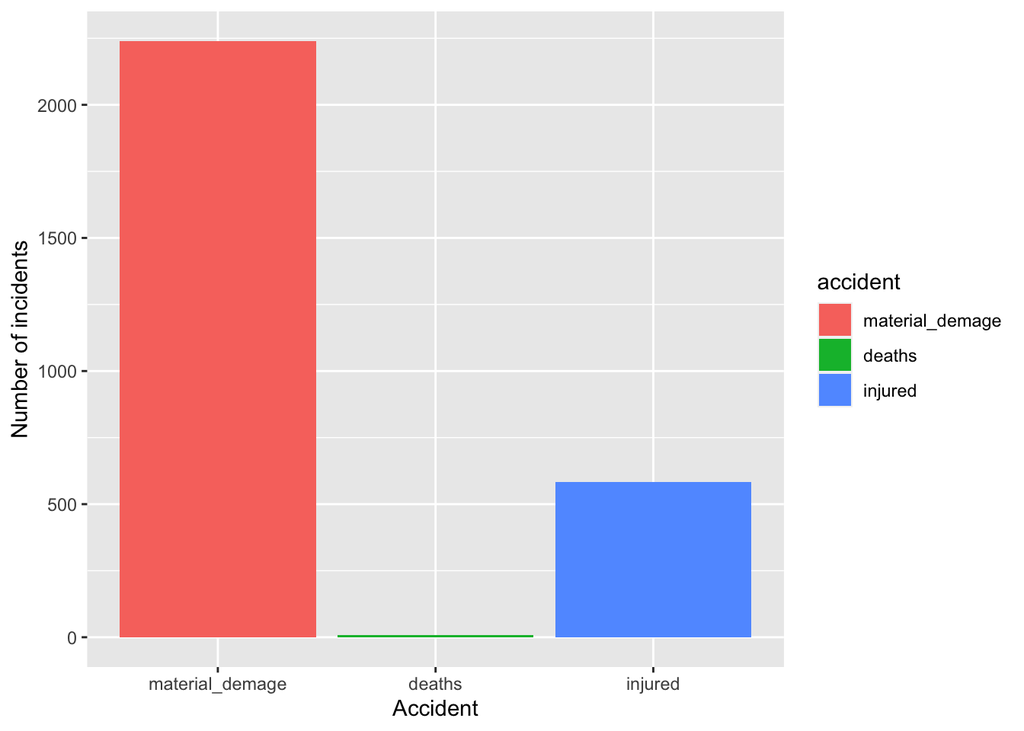

```r
mydata %>%
  group_by(accident) %>%
  ggplot(aes(x = accident, fill = accident)) +
        geom_bar() +
        ylab("Number of incidents") +
        xlab("Accident")
```

To conclude the max values by accident and type_acc are:

```r
mydata %>% group_by(accident) %>% summarize(Count = n()) %>% filter(Count == max(Count))
```

```
## # A tibble: 1 x 2
##   accident        Count
##   <fct>           <int>
## 1 material_demage  2240
```

```r
mydata %>% group_by(type_acc) %>% summarize(Count = n()) %>% filter(Count == max(Count))
```

```
## # A tibble: 1 x 2
##   type_acc            Count
##   <fct>               <int>
## 1 two_vehicle_no_turn   907
```

## Which day in the week has the highest number of accidents?

First we add the weekday column

```r
mydata$weekday = weekdays(mydata$date)
glimpse(mydata)
```

```
## Rows: 2,833
## Columns: 9
## $ id       <int> 1243635, 1240795, 1240864, 1241024, 1240715, 1241608, 1240799…
## $ date     <date> 2019-01-01, 2019-01-01, 2019-01-01, 2019-01-01, 2019-01-01, …
## $ time     <chr> "04:15", "21:05", "16:50", "21:20", "01:50", "05:30", "19:15"…
## $ long     <dbl> 20.49651, 20.46919, 20.45362, 20.47709, 20.26019, 20.45267, 2…
## $ lat      <dbl> 44.81019, 44.79376, 44.79651, 44.81611, 44.29909, 44.88239, 4…
## $ accident <fct> material_demage, material_demage, material_demage, injured, i…
## $ type_acc <fct> parked_vehicle, two_vehicle, two_vehicle_no_turn, two_vehicle…
## $ descrip  <fct> "Sudar sa parkiranim vozilom – bilo sa leve ili sa desne stra…
## $ weekday  <chr> "Tuesday", "Tuesday", "Tuesday", "Tuesday", "Tuesday", "Tuesd…
```

Now we plot the incidents.

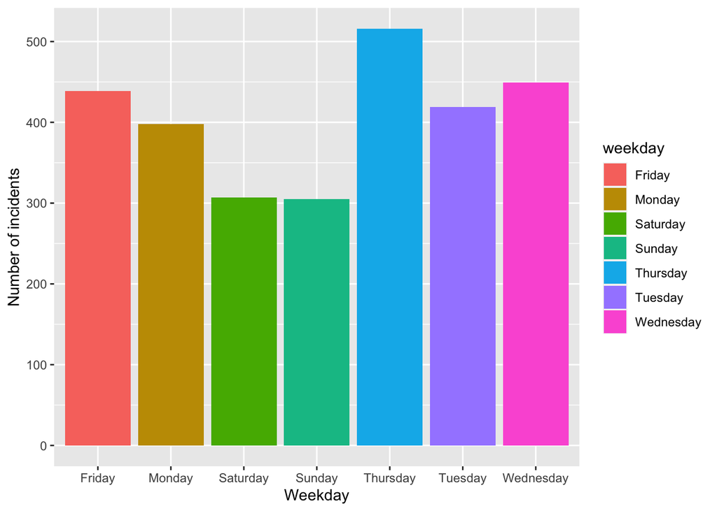

```r
mydata %>%
  group_by(weekday) %>%
  ggplot(aes(x = weekday, fill = weekday)) +
        geom_bar() +
        ylab("Number of incidents") +
        xlab("Weekday")
```

To conclude - the max incidents are:

```r
mydata %>% group_by(weekday) %>% summarize(Count = n()) %>% filter(Count == max(Count))
```

```
## # A tibble: 1 x 2
##   weekday  Count
##   <chr>    <int>
## 1 Thursday   516
```

## For each day in the week find the total number of each kind of accidents?

Let see the numbers

```r
my_summarize <- mydata %>% group_by(weekday, type_acc) %>% summarize(Count = n())
glimpse(my_summarize)
```

```
## Rows: 35
## Columns: 3
## Groups: weekday [7]
## $ weekday  <chr> "Friday", "Friday", "Friday", "Friday", "Friday", "Monday", "…
## $ type_acc <fct> one_vehicle, two_vehicle_no_turn, two_vehicle, parked_vehicle…
## $ Count    <int> 79, 141, 112, 81, 26, 83, 143, 68, 73, 31, 68, 98, 71, 56, 14…
```

And now lets visualize

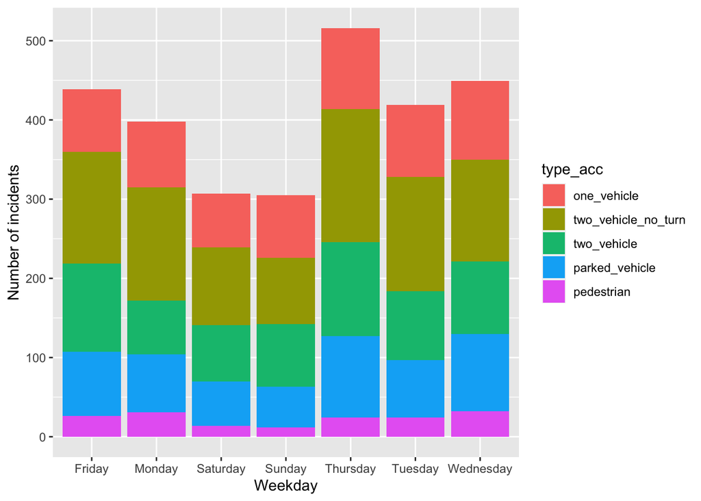

```r
ggplot(data = my_summarize, aes(x = weekday, y=Count, fill=type_acc)) +
      geom_bar(position="stack", stat="identity") +
      ylab("Number of incidents") +
      xlab("Weekday")
```

## Identify time in the day (the hour) with the highest number of accidents

Lets add hour in day column:

```r
mydata$hour_in_day = substring(mydata$time, 0, 2)
glimpse(mydata)
```

```
## Rows: 2,833
## Columns: 10
## $ id          <int> 1243635, 1240795, 1240864, 1241024, 1240715, 1241608, 1240…
## $ date        <date> 2019-01-01, 2019-01-01, 2019-01-01, 2019-01-01, 2019-01-0…
## $ time        <chr> "04:15", "21:05", "16:50", "21:20", "01:50", "05:30", "19:…
## $ long        <dbl> 20.49651, 20.46919, 20.45362, 20.47709, 20.26019, 20.45267…
## $ lat         <dbl> 44.81019, 44.79376, 44.79651, 44.81611, 44.29909, 44.88239…
## $ accident    <fct> material_demage, material_demage, material_demage, injured…
## $ type_acc    <fct> parked_vehicle, two_vehicle, two_vehicle_no_turn, two_vehi…
## $ descrip     <fct> "Sudar sa parkiranim vozilom – bilo sa leve ili sa desne s…
## $ weekday     <chr> "Tuesday", "Tuesday", "Tuesday", "Tuesday", "Tuesday", "Tu…
## $ hour_in_day <chr> "04", "21", "16", "21", "01", "05", "19", "17", "22", "03"…
```

```r
mydata %>% group_by(hour_in_day) %>% summarise(Count = n())
```

```
## # A tibble: 24 x 2
##    hour_in_day Count
##    <chr>       <int>
##  1 00             51
##  2 01             44
##  3 02             31
##  4 03             20
##  5 04             26
##  6 05             29
##  7 06             65
##  8 07            133
##  9 08            143
## 10 09            139
## # … with 14 more rows
```

Lets visualize it:

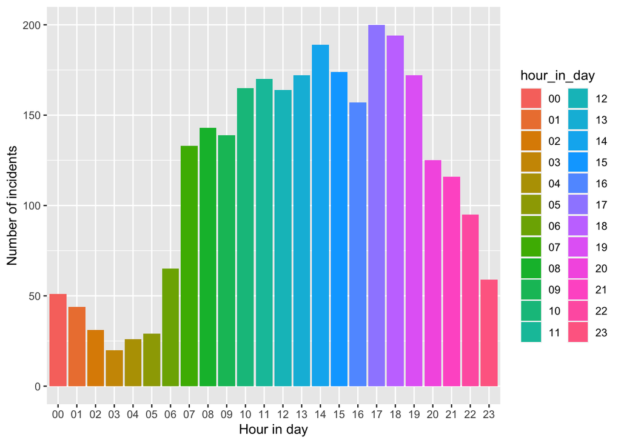

```r
mydata %>%
  group_by(hour_in_day) %>%
  ggplot(aes(x = hour_in_day, fill = hour_in_day)) +
        geom_bar() +
        ylab("Number of incidents") +
        xlab("Hour in day")
```

To conclude:

```r
mydata %>% group_by(hour_in_day) %>% summarize(Count = n()) %>% filter(Count == max(Count))
```

```
## # A tibble: 1 x 2
##   hour_in_day Count
##   <chr>       <int>
## 1 17            200
```

## What is the most occurring type of the accident during the hour with the highest number of accidents?

Lets find the hour with the highest number of accidents.

```r
max_hour <- mydata %>% group_by(hour_in_day) %>% summarize(Count = n()) %>% filter(Count == max(Count))
glimpse(max_hour)
```

```
## Rows: 1
## Columns: 2
## $ hour_in_day <chr> "17"
## $ Count       <int> 200
```

We’re filtering the data - only the data of that single max hour.

```r
my_max_hour_data <- mydata %>% group_by(type_acc) %>% filter(hour_in_day == max_hour$hour_in_day)
glimpse(my_max_hour_data)
```

```
## Rows: 200
## Columns: 10
## Groups: type_acc [5]
## $ id          <int> 1240770, 1240762, 1241800, 1241542, 1240891, 1241000, 1241…
## $ date        <date> 2019-01-01, 2019-01-01, 2019-01-02, 2019-01-02, 2019-01-0…
## $ time        <chr> "17:00", "17:40", "17:00", "17:00", "17:00", "17:30", "17:…
## $ long        <dbl> 20.43913, 20.52735, 20.46497, 20.55739, 20.46692, 20.37892…
## $ lat         <dbl> 44.74523, 44.77881, 44.79578, 44.56445, 44.84735, 44.80537…
## $ accident    <fct> material_demage, material_demage, material_demage, injured…
## $ type_acc    <fct> two_vehicle_no_turn, one_vehicle, two_vehicle_no_turn, two…
## $ descrip     <fct> "Najmanje dva vozila – suprotni smerovi bez skretanja – kr…
## $ weekday     <chr> "Tuesday", "Tuesday", "Wednesday", "Wednesday", "Wednesday…
## $ hour_in_day <chr> "17", "17", "17", "17", "17", "17", "17", "17", "17", "17"…
```

```r
my_max_hour_data %>% group_by(type_acc) %>% summarize(Count = n()) %>% filter(Count == max(Count))
```

```
## # A tibble: 1 x 2
##   type_acc            Count
##   <fct>               <int>
## 1 two_vehicle_no_turn    73
```

Now lets visualize.

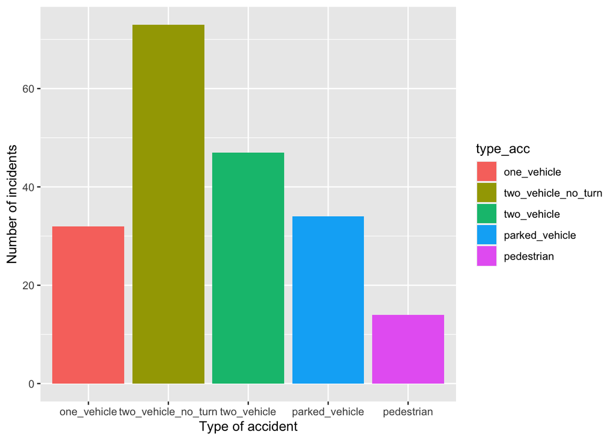

```r
my_max_hour_data %>%
  group_by(type_acc) %>%
  ggplot(aes(x = type_acc, fill = type_acc)) +
        geom_bar() +
        ylab("Number of incidents") +
        xlab("Type of accident")
```

## Creat a leafleta interactive map to pinpoint the accidents with the popup message of the description of the accidents.

This popup message should appear every time a user clicks on an accident marker.

Here you go.:)

```r
minlat <- min(mydata$lat)
maxlat <- max(mydata$lat)
minlng <- min(mydata$long)
maxlng <- max(mydata$long)

libs <- mydata %>%
  leaflet() %>%
  # add tiles to the leaflet object
  addTiles() %>%
  # setting the corners/centre of the map
  fitBounds(~minlng, ~minlat, ~maxlng, ~maxlat) %>%
  # add the markers with the popups
  addCircles(lng = ~long, lat = ~lat,
             radius = 150, weight = 10, color = "black",
             fillColor = "red", fillOpacity = 0.7,
             popup = ~paste(descrip))
#print the map
libs
```

[interactive chart not shown]

## [Assignment Problem 2](http://tanjakec.github.io/Project_DSBC/AssignmentQs.html#Problem_2)

# Part I

## Explain what is meant by the following terms:

- Population - Statistical data set
- Response variable - A response variable is a variable that measures either directly or indirectly the objectives of the analysis.
- Explanatory Variable - An explanatory variable is a variable that may influence the response variable.
- Sample Descriptive Statistics - simple analysis on a sample of the datasource, with the goal of investigating the relationship between variables

## What is the ‘Data Analysis Methodology’, and why is this needed when working with sample data?

It is the methodology for investigation the relationship between response and explanatory variables. The first step is to identify the response variable and the explanatory variable under investigation, which will provide a framework for defining a Data Analysis process to explore the connection between the two variables. By using simple sample descriptive statistics we can start to investigate the nature of the link between the variables. There might be strong evidence within the sample to support a link, or it might lead us to the conclusion that there is no evidence of a link, or that the simple approach is inconclusive and further more sophisticated data analysis is required.

## What are the statistical concepts used to investigate the relationship between a measured response and an attribute explanatory variable?

## How are these statistical concepts translated into operational procedures

for sample data with:

- an attribute explanatory variable having two levels
- an attribute explanatory variable having three or more levels; hence explain when and why a Tukey test is helpful

## How does multiple regression differ from simple linear regression?

We use multiple regression when there are more than one explanatory variables.

## In multiple regression how is the contribution of each individual explanatory variable to the regression model initially assessed?

# Part II

```r
fish <- read.csv("data/Fish.csv",
                   na.strings = c("","NA"),
                   stringsAsFactor = FALSE)
glimpse(fish)
```

```
## Rows: 159
## Columns: 7
## $ Species <chr> "Bream", "Bream", "Bream", "Bream", "Bream", "Bream", "Bream",…
## $ Weight  <dbl> 242, 290, 340, 363, 430, 450, 500, 390, 450, 500, 475, 500, 50…
## $ Length1 <dbl> 23.2, 24.0, 23.9, 26.3, 26.5, 26.8, 26.8, 27.6, 27.6, 28.5, 28…
## $ Length2 <dbl> 25.4, 26.3, 26.5, 29.0, 29.0, 29.7, 29.7, 30.0, 30.0, 30.7, 31…
## $ Length3 <dbl> 30.0, 31.2, 31.1, 33.5, 34.0, 34.7, 34.5, 35.0, 35.1, 36.2, 36…
## $ Height  <dbl> 11.5200, 12.4800, 12.3778, 12.7300, 12.4440, 13.6024, 14.1795,…
## $ Width   <dbl> 4.0200, 4.3056, 4.6961, 4.4555, 5.1340, 4.9274, 5.2785, 4.6900…
```

Lets turn the attribute variable Species into a numerical representation

```r
fish$Species_num = as.numeric(factor(fish$Species))
glimpse(fish)
```

```
## Rows: 159
## Columns: 8
## $ Species     <chr> "Bream", "Bream", "Bream", "Bream", "Bream", "Bream", "Bre…
## $ Weight      <dbl> 242, 290, 340, 363, 430, 450, 500, 390, 450, 500, 475, 500…
## $ Length1     <dbl> 23.2, 24.0, 23.9, 26.3, 26.5, 26.8, 26.8, 27.6, 27.6, 28.5…
## $ Length2     <dbl> 25.4, 26.3, 26.5, 29.0, 29.0, 29.7, 29.7, 30.0, 30.0, 30.7…
## $ Length3     <dbl> 30.0, 31.2, 31.1, 33.5, 34.0, 34.7, 34.5, 35.0, 35.1, 36.2…
## $ Height      <dbl> 11.5200, 12.4800, 12.3778, 12.7300, 12.4440, 13.6024, 14.1…
## $ Width       <dbl> 4.0200, 4.3056, 4.6961, 4.4555, 5.1340, 4.9274, 5.2785, 4.…
## $ Species_num <dbl> 1, 1, 1, 1, 1, 1, 1, 1, 1, 1, 1, 1, 1, 1, 1, 1, 1, 1, 1, 1…
```

Lets visualize the weight per species to get a grasp

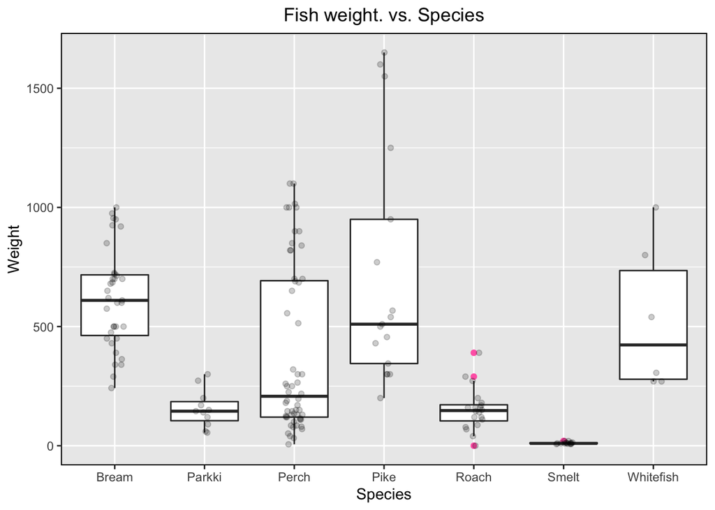

```r
ggplot(fish, aes(x = Species, y = Weight)) +
  geom_boxplot(outlier.colour = "hotpink") +
  geom_jitter(position = position_jitter(width = 0.1, height = 0), alpha = .2) +
  labs (title= "Fish weight. vs. Species",
        x = "Species", y = "Weight") +
  theme(legend.position = "none",
        panel.border = element_rect(fill = NA,
                                    colour = "black",
                                    size = .75),
        plot.title=element_text(hjust=0.5))
```

Let see the mean values per species

```r
fish %>%
    group_by(Species) %>%
    summarise(mean=mean(Weight))
```

```
## # A tibble: 7 x 2
##   Species    mean
##   <chr>     <dbl>
## 1 Bream     618.
## 2 Parkki    155.
## 3 Perch     382.
## 4 Pike      719.
## 5 Roach     152.
## 6 Smelt      11.2
## 7 Whitefish 531
```

Lets examine the pairwise plot

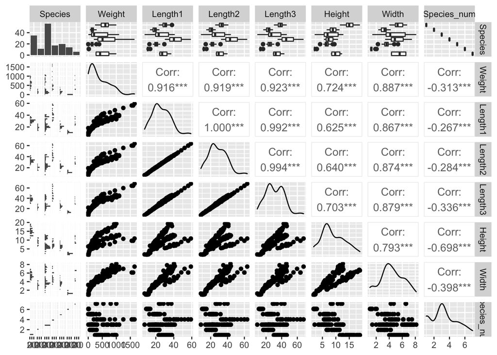

```r
ggpairs(fish)
```

Lets try the model with all of the variables

```r
model_1 <- lm(Height ~ ., data = fish) # full stop, . , implies: all other variables in data that do not already appear in the formula
summary(model_1)
```

```
##
## Call:
## lm(formula = Height ~ ., data = fish)
##
## Residuals:
##      Min       1Q   Median       3Q      Max
## -1.93193 -0.26715 -0.00155  0.26923  1.85551
##
## Coefficients: (1 not defined because of singularities)
##                    Estimate Std. Error t value Pr(>|t|)
## (Intercept)       4.8072649  0.8457595   5.684 6.85e-08 ***
## SpeciesParkki    -1.8579528  0.4607772  -4.032 8.84e-05 ***
## SpeciesPerch     -5.2114885  0.6304401  -8.266 7.50e-14 ***
## SpeciesPike      -7.7045958  0.5812054 -13.256  < 2e-16 ***
## SpeciesRoach     -4.7923659  0.4230867 -11.327  < 2e-16 ***
## SpeciesSmelt     -5.3661495  0.6532114  -8.215 1.01e-13 ***
## SpeciesWhitefish -4.4972697  0.4870806  -9.233 2.69e-16 ***
## Weight            0.0002093  0.0005205   0.402    0.688
## Length1          -0.3111477  0.2314242  -1.344    0.181
## Length2           0.1793095  0.2912636   0.616    0.539
## Length3           0.2071286  0.1849836   1.120    0.265
## Width             1.0677290  0.1226400   8.706 5.92e-15 ***
## Species_num              NA         NA      NA       NA
## ---
## Signif. codes:  0 '***' 0.001 '**' 0.01 '*' 0.05 '.' 0.1 ' ' 1
##
## Residual standard error: 0.5924 on 147 degrees of freedom
## Multiple R-squared:  0.9822, Adjusted R-squared:  0.9809
## F-statistic: 738.5 on 11 and 147 DF,  p-value: < 2.2e-16
```

We can see that the lenghts have strong correlations with each other